# STA 209 – Exam 2 Formula Sheet

# CI for a single population proportion (p)

### Conditions

1. The data comes from a random sample.
2. $n * \widehat{p} \geq 10$ (Success Condition)
3. $n * (1-\widehat{p}) \geq 10$ (Failure Condition)

### Formula

$\widehat{p} \pm z^* \times \sqrt{\frac{\widehat{p}(1-\widehat{p})}{n}}$

$z^*$ is the appropriate value from the normal distribution that gives us the Confidence % that we want

- 95% Confidence → $z^*$ = 1.96
- 80% Confidence → $z^*$ = 1.282
- 90% Confidence → $z^*$ = 1.645
- 99% Confidence → $z^*$ = 2.576

# CI for a difference in population proportions ($p_1 - p_2$)

### Conditions

1. Data for both groups is representative, both groups independent.
2. $n_1 * \widehat{p}_1 \geq 10$ (Success Condition Grp 1)
3. $n_1 * (1-\widehat{p}_1) \geq 10$ (Failure Condition Grp 1)
4. $n_2 * \widehat{p}_2 \geq 10$ (Success Condition Grp 2)
5. $n_2 * (1-\widehat{p}_2) \geq 10$ (Failure Condition Grp 2)

### Formula

$(\widehat{p}_1 - \widehat{p}_2) \pm z^* \times \sqrt{\frac{\widehat{p}_1(1-\widehat{p}_1)}{n_1}+\frac{\widehat{p}_2(1-\widehat{p}_2)}{n_2}}$

$z^*$ is the appropriate value from the normal distribution that gives us the Confidence % that we want

- 95% Confidence → $z^*$ = 1.96
- 80% Confidence → $z^*$ = 1.282
- 90% Confidence → $z^*$ = 1.645
- 99% Confidence → $z^*$ = 2.576

# Confidence Interval for a Single Mean

### 100(1-$\alpha$)% Confidence Interval Formula ($\sigma$ unknown)

### $\overline{x} \pm t_{(1-\alpha/2, df=n-1)} \times \frac{s}{\sqrt{n}}$

where $t_{(1-\alpha/2, df=n-1)}$ is the $1-\alpha/2$ quantile for a t-distribution with n-1 degrees of freedom (use `qt()` to get final values).

# Confidence Interval for Difference in Means

### Conditions

1. The *populations* are Normal **OR** the both sample sizes $n_1 \geq 30$ and $n_2 \geq 30$
2. There was a random sample for both groups.

### 100(1-$\alpha$)% Confidence Interval Formula ($\sigma$ unknown)

### ($\overline{x}_1 - \overline{x}_2) \pm t_{(1-\alpha/2, df)} \times \sqrt{\frac{s_1^2}{n_1} + \frac{s_2^2}{n_2}}$

where $t_{(1-\alpha/2, df)}$ is the $1-\alpha/2$ quantile for a t-distribution with degrees of freedom $df=min(n_1, n_2)-1$ (use `qt()` to get final values).

# Strength of Evidence Chart

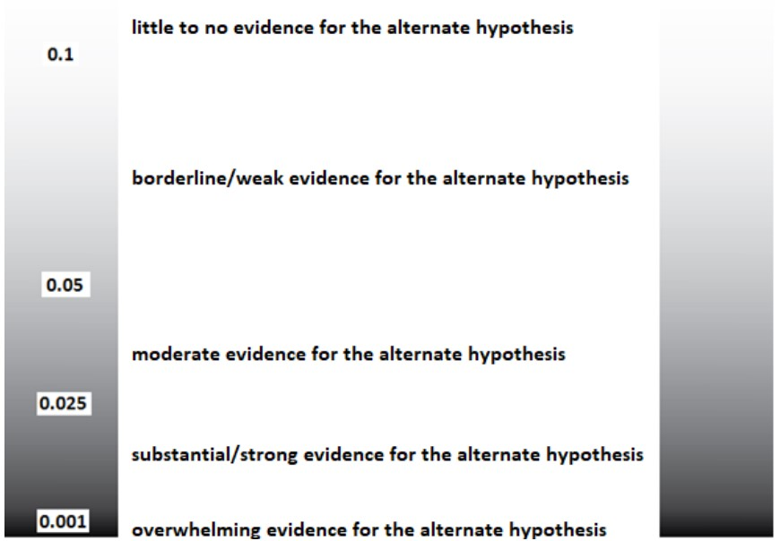